# Exploring_Chicago_Pt1

Lauren Shores

5/13/2020

## Intro

The purpose of this analysis is to explore the distribution of different metrics across the city at the census block group level. These metrics include:

*median household income* population density *race* crime *access to businesses* access to public transportation

## Getting Started

First we need to read in the data. It’s going to be helpful to think about Chicago in terms of neighborhoods, so will bring in a community areas shapefile.

We also have our first few metrics in a dataset that was pulled from NHGHIS, so we’ll bring that in as well. This data is for all counties in IL, so we will just focus on Cook County.

Check out the plots

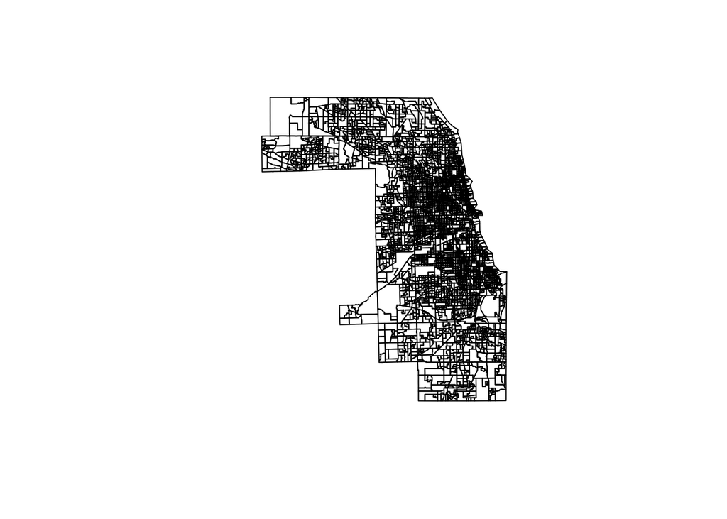

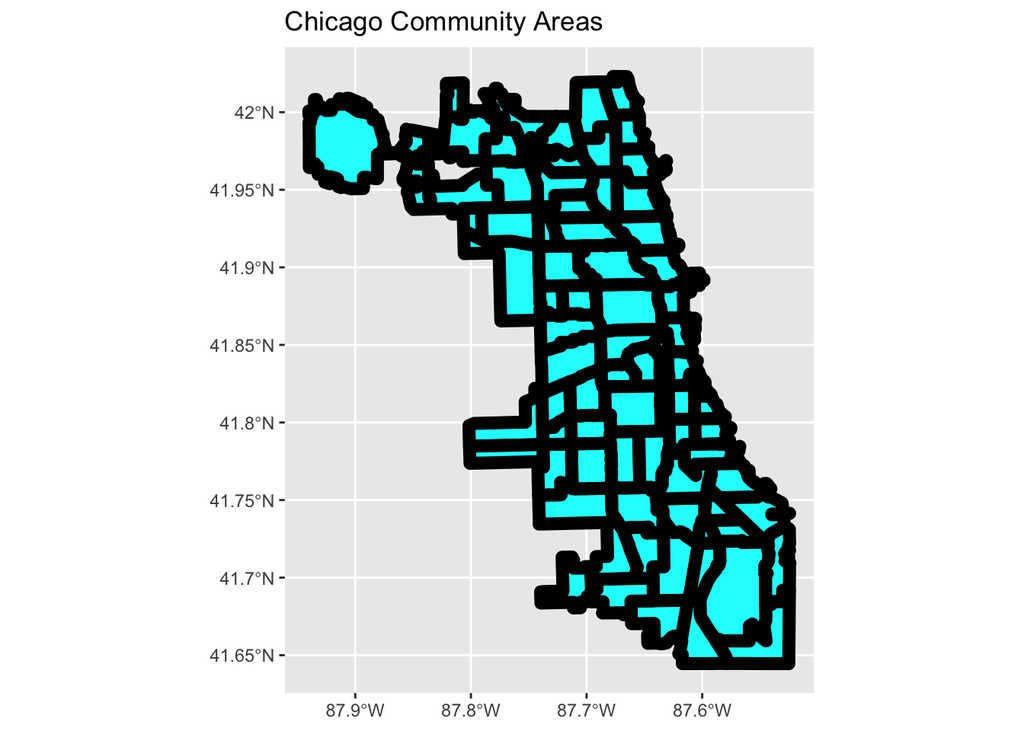

Check the demographic data for missing values, etc. There are 159 block groups that do not have income information. This is going to be important information in grouping our block groups. Let’s try to impute the income values by building a regression model

```
## [1] 159
```

```
## [1] 0
```

```
## [1] 0
```

```
## [1] 0
```

```
## [1] 0
```

## Imputing Missing HHIncome

Will first try a regression with most of the variables to get HH Income values for the missing block groups. In certain categories, will just keep one variable because they’re highly correlated (ex:high employed, low unemployed, etc)

```
## R_squared on the test data:
```

```
## [1] 0.37
```

```
## Root mean square error on the test data:
```

```
## [1] 29935.49
```

```
## Mean Absolute Percent Error on the test data (MAPE):
```

```
## [1] 0.3875286
```

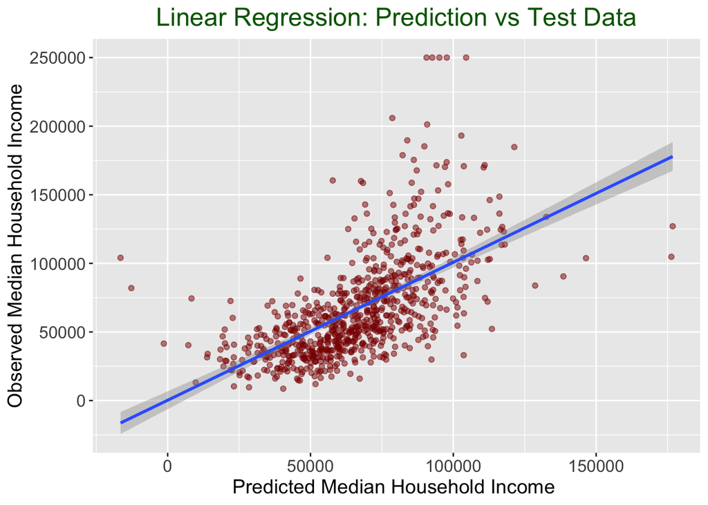

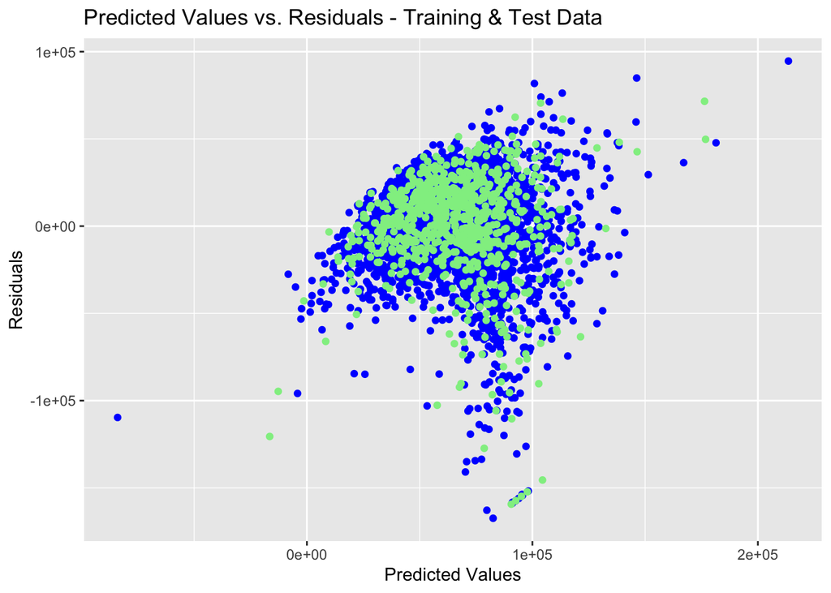

With a mape of .39, the above result isn’t great. Let’s try to make more succinct features by creating percentages for the demographics rather than absolute values, and then use that in the model

Below we see that using the percent variables had a marked improvement on Rsquare and error (R-square improved by .16 and mape went down by .06).

```
## R_squared on the test data:
```

```
## [1] 0.53
```

```
## Root mean square error on the test data:
```

```
## [1] 25910.64
```

```
## Mean Absolute Percent Error on the test data (MAPE):
```

```
## [1] 0.3221048
```

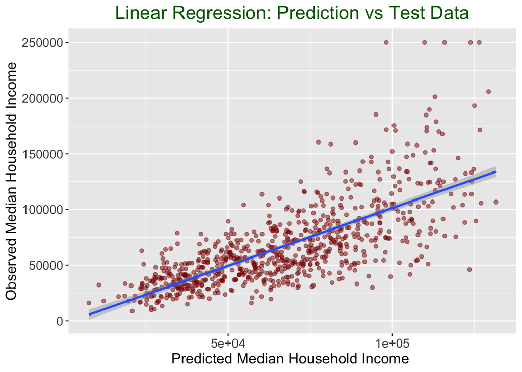

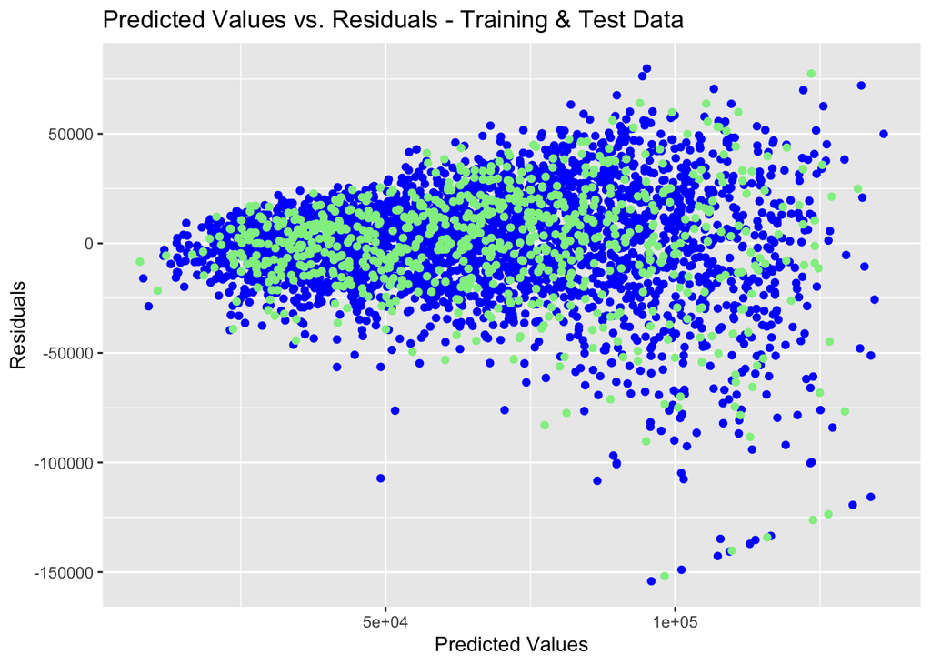

But our residuals plot does have a bit of a funnel shape, which indicates that a log or square transformation of the y variable may be appropriate. A log transform of y brings the R-square up to .59 and the mape down to .025! Also, no more funnel shape in the residuals plot (we now have equal variances/homoskedasticity)

```
## R_squared on the test data:
```

```
## [1] 0.59
```

```
## Root mean square error on the test data:
```

```
## [1] 0.35
```

```
## Mean Absolute Percent Error on the test data (MAPE):
```

```
## [1] 0.02540804
```

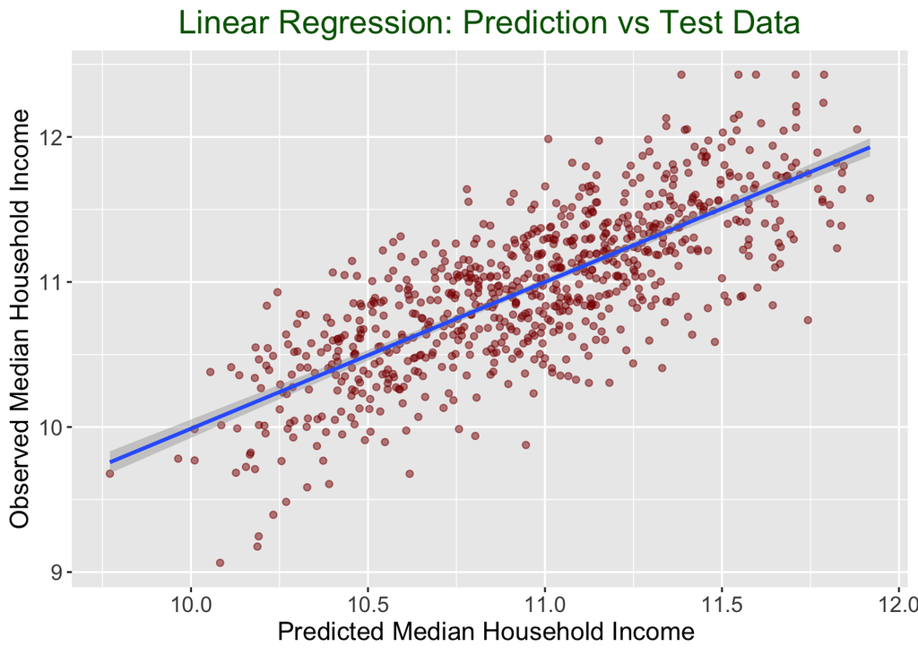

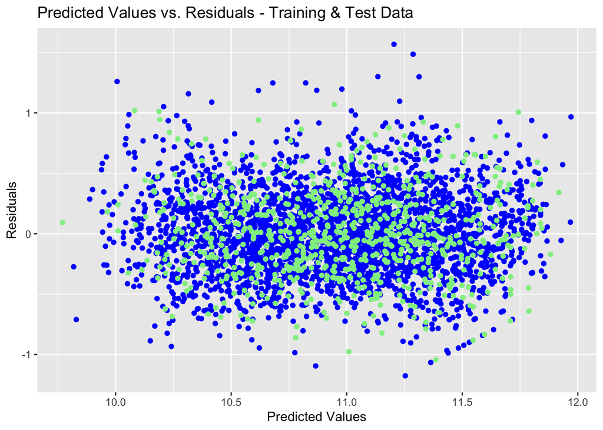

Now let’s predict our missing income values

```
## count of blockgrps that did not get a prediction:
```

```
## [1] 11
```

```
##      Median_HHIncome CensusTractCode BlockGrpCode TotalPopulation White_Perc
## 3970        41864.75          842900            4             267 0.44943820
## 3986        25345.58          843900            1             973 0.02672148
## 3987        23749.84          843900            2             420 0.03095238
## 3991             NaN          980000            1               0        NaN
## 3992             NaN          980100            1               0        NaN
## 3993             NaN          990000            0               0        NaN
##      Black_Perc Asian_Perc OtherRace_Perc Bachelors_Perc Masters_Perc
## 3970  0.2509363          0     0.29962547      0.1359223   0.06310680
## 3986  0.9383350          0     0.01130524      0.1090630   0.01689708
## 3987  0.9690476          0     0.00000000      0.1058496   0.00000000
## 3991        NaN        NaN            NaN            NaN          NaN
## 3992        NaN        NaN            NaN            NaN          NaN
## 3993        NaN        NaN            NaN            NaN          NaN
##      ProfDegree_Perc Doctorate_Perc InLaborForce_Perc Employed_Perc
## 3970               0     0.00000000         0.3691589     1.0000000
## 3986               0     0.01689708         0.2367448     0.8385417
## 3987               0     0.01114206         0.3887399     0.7103448
## 3991             NaN            NaN               NaN           NaN
## 3992             NaN            NaN               NaN           NaN
## 3993             NaN            NaN               NaN           NaN
##      Unemployed_Perc Median_HHIncome_Perc TotalPop_Perc
## 3970       0.0000000                   NA    0.02649072
## 3986       0.1614583                   NA    0.09653735
## 3987       0.2896552                   NA    0.04167080
## 3991             NaN                   NA    0.00000000
## 3992             NaN                   NA    0.00000000
## 3993             NaN                   NA    0.00000000
```